# R Notebook

# TP3

## Pré-traitement

### Récupération des données

importation des modules

`r`r library(Matrix) library(NLP) library(tm) library(irlba) library(stats) library(pROC)

`r`r library(parallel)

On construit des objects SimpleCorpus du package Text Mining

Sur ces coprus, on supprime les nombres, la ponctuation, et on transforme toutes les majuscules en minuscules

`r`r get_data <- function(src) { corpus <- SimpleCorpus(DirSource(src)) corpus <- tm_map(corpus, removeNumbers) corpus <- tm_map(corpus, removePunctuation) corpus <- tm_map(corpus, content_transformer(tolower)) return(corpus) }

corpus_poly <- get_data(‘data/Poly’) corpus_udm <- get_data(‘data/UdM’) corpus_hec <- get_data(‘data/HEC’) corpus_uqam <- get_data(‘data/UQAM’)

head(data.frame(text = sapply(corpus_poly, as.character)))

|  | text |
| --- | --- |
| AE3100.txt | titrecours matriaux et procds en aronautique\ndescriptioncours mtaux utiliss en aronautique et procds de transformation analyse de dfaillance procds chimiques et prvention de la corrosion matriaux com… |
| AE3205.txt | titrecours caractristiques de lavion\ndescriptioncours cours dintroduction laronautique historique de laronautique arodynamique structure performances poste de pilotage et instrumentation propulsion s… |
| AE3300.txt | titrecours arodynamique de lavion i\ndescriptioncours coulements visqueux couches limites laminaires en coulement plan stabilit des couches limites transition du rgime laminaire au rgime turbulent cou… |
| AE3400.txt | titrecours commande de vol\ndescriptioncours introduction historique action des gouvernes modle mathmatique dun avion rigide linarisation dcouplage des mouvements quations dtat fonctions de transfert … |
| AE3900.txt | titrecours projet intgrateur iii\ndescriptioncours projet individuel choisi par ltudiant et ralis sous la direction dun professeur du dpartement de gnie mcanique ou de tout autre ingnieur agr par le d… |
| AE3900A.txt | titrecours projet intgrateur iii\ndescriptioncours projet individuel choisi par ltudiant et ralis sous la direction dun professeur du dpartement de gnie mcanique ou de tout autre ingnieur agr par le d… |

On va ensuite construire un grand corpus regroupant les corpus des 4 écoles

`r`r corpus_tot <- get_data(c(‘data/Poly’, ‘data/UdM’, ‘data/HEC’, ‘data/UQAM’))

### Matrices Termes-Documents

On utilise le package TM pour construire des matrices terme-document

On supprime avant cela les “stop words”, mots très fréquents et que l’on retrouve dans tous les corpus de textes francais. Ces mots ne comportent pas de sémantique particulière (comme les prépositions, etc…) On supprime aussi les deux groupes nominaux “titrecours” et “descriptioncours” qui seront en quantité égale dans tous les documents et qui par conséquents ne sont pas utiles dans ce travail

`r`r to_matrix <- function(corpus) { corpus <- tm_map(corpus,removeWords, stopwords(‘french’)) corpus <- tm_map(corpus, removeWords, c(‘titrecours’, ‘descriptioncours’)) return(TermDocumentMatrix(corpus)) }

td_poly <- to_matrix(corpus_poly) td_udm <- to_matrix(corpus_udm) td_hec <- to_matrix(corpus_hec) td_uqam <- to_matrix(corpus_uqam)

td_tot <- to_matrix(corpus_tot)

`r`r as.data.frame(as.matrix(td_tot[0:10, 0:10]))

|  | 1-404-96.txt | 1-407-00.txt | 1-409-05.txt | 1-611-09.txt | 1-611-96.txt | 1-612-96.txt | 1-613-07.txt | 1-620-07.txt | 1-628-07.txt | 1-803-07.txt |
| --- | --- | --- | --- | --- | --- | --- | --- | --- | --- | --- |
| aborder | 1 | 0 | 0 | 0 | 0 | 0 | 0 | 0 | 0 | 0 |
| actuellement | 1 | 0 | 0 | 0 | 0 | 0 | 0 | 0 | 0 | 0 |
| ainsi | 1 | 0 | 0 | 0 | 0 | 0 | 0 | 0 | 0 | 2 |
| apprehender | 1 | 0 | 0 | 0 | 0 | 0 | 0 | 0 | 0 | 0 |
| auxquels | 1 | 0 | 0 | 0 | 0 | 0 | 0 | 0 | 0 | 0 |
| changements | 1 | 0 | 0 | 0 | 0 | 0 | 0 | 0 | 0 | 0 |
| comparative | 1 | 0 | 0 | 0 | 0 | 0 | 0 | 0 | 0 | 0 |
| comptable | 1 | 0 | 0 | 0 | 0 | 0 | 0 | 0 | 0 | 0 |
| concepts | 1 | 0 | 0 | 0 | 2 | 0 | 0 | 0 | 0 | 0 |
| confrontees | 1 | 0 | 0 | 0 | 0 | 0 | 0 | 0 | 0 | 0 |

Une fois la matrice terme-document définie, on va définir la matrice Tf-Idf

`r`r get_Tf_IDF <- function(td) { tf <- as.matrix(td) tf_copy <- tf tf_copy[tf_copy != 0] <- 1 n_i <- rowSums(tf_copy) idf <- log(nDocs(td_tot)/n_i) tf_idf = tf * idf return(tf_idf) }

tf_idf <- Matrix(get_Tf_IDF(td_tot), )

```
'nrow', 'ncol', etc, are disregarded for matrix 'data'
```

`r`r as.data.frame(as.matrix(tf_idf[, 0:9]))

|  | 1-404-96.txt | 1-407-00.txt | 1-409-05.txt | 1-611-09.txt | 1-611-96.txt | 1-612-96.txt | 1-613-07.txt | 1-620-07.txt | 1-628-07.txt |
| --- | --- | --- | --- | --- | --- | --- | --- | --- | --- |
| aborder | 5.730773 | 0.000000 | 0.000000 | 0.000000 | 0.000000 | 0.000000 | 0.000000 | 0.000000 | 0.000000 |
| actuellement | 6.267078 | 0.000000 | 0.000000 | 0.000000 | 0.000000 | 0.000000 | 0.000000 | 0.000000 | 0.000000 |
| ainsi | 2.724717 | 0.000000 | 0.000000 | 0.000000 | 0.000000 | 0.000000 | 0.000000 | 0.000000 | 0.000000 |
| apprehender | 6.299868 | 0.000000 | 0.000000 | 0.000000 | 0.000000 | 0.000000 | 0.000000 | 0.000000 | 0.000000 |
| auxquels | 5.542182 | 0.000000 | 0.000000 | 0.000000 | 0.000000 | 0.000000 | 0.000000 | 0.000000 | 0.000000 |
| changements | 4.547774 | 0.000000 | 0.000000 | 0.000000 | 0.000000 | 0.000000 | 0.000000 | 0.000000 | 0.000000 |
| comparative | 4.905275 | 0.000000 | 0.000000 | 0.000000 | 0.000000 | 0.000000 | 0.000000 | 0.000000 | 0.000000 |
| comptable | 5.201256 | 0.000000 | 0.000000 | 0.000000 | 0.000000 | 0.000000 | 0.000000 | 0.000000 | 0.000000 |
| concepts | 2.629492 | 0.000000 | 0.000000 | 0.000000 | 5.258984 | 0.000000 | 0.000000 | 0.000000 | 0.000000 |
| confrontees | 6.405228 | 0.000000 | 0.000000 | 0.000000 | 0.000000 | 0.000000 | 0.000000 | 0.000000 | 0.000000 |

[output cut: 990 more lines]

On reduit le nombre de dimension de la matrice. On transposera la matrice auparavant pour obtenir une matrice document-terme.

`r`r dim_redu = 50

m.svd <- irlba(t(tf_idf), 50) reduce_tf_idf <- m.svd$u[, 1:dim_redu] %*% diag(m.svd$d[1:dim_redu]) rownames(reduce_tf_idf) <- colnames(tf_idf)

`r`r as.data.frame(as.matrix(reduce_tf_idf[, 1:9]))

|  | V1 | V2 | V3 | V4 | V5 | V6 | V7 | V8 | V9 |
| --- | --- | --- | --- | --- | --- | --- | --- | --- | --- |
| X1.404.96.txt | 4.049576e-01 | 7.185698e+00 | -2.631227e+00 | -2.887801371 | 6.056646e-01 | 9.690073e-01 | -5.786216e-01 | -1.736701e+00 | 1.602580e+00 |
| X1.407.00.txt | 2.732854e+00 | 8.615672e+00 | 3.192441e-01 | -2.872846315 | 1.082059e+00 | 3.668948e+00 | 2.253099e+00 | -1.598918e+00 | 1.143880e+00 |
| X1.409.05.txt | 7.842637e-01 | 2.001730e+00 | -5.041294e+00 | 3.236029155 | -2.263449e-01 | -2.809371e+00 | 2.232263e-01 | -3.003670e+00 | -1.000873e+01 |
| X1.611.09.txt | 2.793736e-03 | 9.812644e-02 | -2.649079e-02 | -0.135583688 | 2.285165e-03 | 1.471560e-01 | 2.197355e-02 | 1.107431e-02 | -1.606982e-01 |
| X1.611.96.txt | 4.362204e-01 | 7.379816e+00 | -8.125000e-01 | -2.534727163 | 6.183997e-01 | 2.839836e+00 | 2.555268e-01 | -6.649959e-01 | -6.304148e-02 |
| X1.612.96.txt | 1.306301e-01 | 3.210961e+00 | 2.254912e-02 | -0.569155706 | -7.919584e-01 | 1.059070e+00 | -3.988615e-01 | -2.683299e-01 | 4.132026e-01 |
| X1.613.07.txt | 3.262703e-04 | 1.894457e-02 | -4.336435e-04 | -0.025839773 | -1.689586e-02 | 1.744655e-02 | -1.359503e-02 | -1.090332e-02 | -2.747408e-02 |
| X1.620.07.txt | 8.003782e-04 | 4.490989e-02 | 2.668136e-03 | -0.060387008 | -6.941159e-03 | 4.270696e-02 | 2.359418e-02 | 2.962383e-02 | -1.044276e-01 |
| X1.628.07.txt | 9.021549e-03 | 2.953488e-03 | -2.432805e-02 | 0.021261214 | 1.445468e-02 | -1.551375e-02 | -2.923812e-02 | 8.414429e-03 | -1.251301e-02 |
| X1.803.07.txt | 1.563190e+00 | 8.520903e+00 | -5.621330e+00 | 1.040053438 | -4.135671e-01 | -8.928491e-01 | -7.856463e-01 | -5.221485e-01 | -1.238403e+00 |

[output cut: 990 more lines]

## Question 1

**Quels sont les 10 cours les plus similaires à LOG2420 dans l’espace réduit à 50 dimensions?**

On va dans un premier temps récupérer les fonctions de similarité de la correction du TP1

`r`r ## Cosinus entre un vecteur v et chaque colonne dela matrice m cosinus.vm <- function(v,m) { n <- sqrt(colSums(m^2)); (v %*% m)/(n* sqrt(sum(v^2))) } ## Cosinus des colonnes d’une matrice cosinus.mm <- function(m) { n <- sqrt(colSums(m^2)); crossprod(m)/(n %o% n) } # Trouve les indexes des premiÃ¨res ‘n’ valeurs maximales d’une matrice max.nindex <- function(m, n=5) { i <- order(m, decreasing=TRUE) return(i[1:n]) } min.nindex <- function(m, n=5) { i <- order(m) return(i[1:n]) }

On va ensuite sélectionner l’indice du cours LOG2420

`r`r i <- grep(‘LOG2420’, as.character(rownames(reduce_tf_idf)))

On va enfin calculer la similarité des documents entre-eux, avec la méthode des cosinus (on transpose la matrice pour obtenir une matrice terme-document).

`r`r reduce_tf_idf.cos <- cosinus.mm(t(reduce_tf_idf))

`r`r head(as.data.frame(as.matrix(reduce_tf_idf.cos[,1:6])))

|  | 1-404-96.txt | 1-407-00.txt | 1-409-05.txt | 1-611-09.txt | 1-611-96.txt | 1-612-96.txt |
| --- | --- | --- | --- | --- | --- | --- |
| X1.404.96.txt | 1.00000000 | 0.334368316 | 0.018548401 | 0.044329410 | 0.47908927 | 0.359766569 |
| X1.407.00.txt | 0.33436832 | 1.000000000 | -0.002951045 | 0.046585383 | 0.47586926 | 0.200203892 |
| X1.409.05.txt | 0.01854840 | -0.002951045 | 1.000000000 | -0.000909936 | -0.00431363 | -0.002846353 |
| X1.611.09.txt | 0.04432941 | 0.046585383 | -0.000909936 | 1.000000000 | 0.37805811 | 0.172936163 |
| X1.611.96.txt | 0.47908927 | 0.475869257 | -0.004313630 | 0.378058110 | 1.00000000 | 0.704078843 |
| X1.612.96.txt | 0.35976657 | 0.200203892 | -0.002846353 | 0.172936163 | 0.70407884 | 1.000000000 |

On sélectionne les 10 cours les plus proches de LOG2420.

`r`r i.sim.cos <- max.nindex(reduce_tf_idf.cos[,i], 11) data.frame(Cos=reduce_tf_idf.cos[i.sim.cos, i], Index=i.sim.cos)

|  | Cos | Index |
| --- | --- | --- |
| LOG2420.txt | 1.0000000 | 1891 |
| INF8701.txt | 0.8838758 | 1880 |
| INF8500.txt | 0.8475031 | 1878 |
| MEC8311A.txt | 0.8414137 | 2023 |
| INF6600.txt | 0.8299229 | 1853 |
| IFT3911.txt | 0.8221239 | 4881 |
| INF7215.txt | 0.8207535 | 12449 |
| MGL7361.txt | 0.8145883 | 14158 |
| IFT2255.txt | 0.8127184 | 4843 |
| INF6305.txt | 0.8077443 | 1844 |

[output cut: 1 more lines]

## Question 2

**Effectuez une classification de cours par une approche supervisée**

Dans un premier temps on va sélectionner les index des cours qui nous intéressent :

`r`r reduce_tf_idf.class <- subset(reduce_tf_idf, grepl(|PHY, rownames(reduce_tf_idf)))

reduce_tf_idf.PSY <- subset(reduce_tf_idf, grepl(, rownames(reduce_tf_idf)))

reduce_tf_idf.PHY <- subset(reduce_tf_idf, grepl(, rownames(reduce_tf_idf)))

Voila le résultat pour la classe PSY :

`r`r as.data.frame(as.matrix(reduce_tf_idf.PSY[,0:9]))

|  | V1 | V2 | V3 | V4 | V5 | V6 | V7 | V8 | V9 |
| --- | --- | --- | --- | --- | --- | --- | --- | --- | --- |
| PSY1004.txt | 0.08401436 | 1.0048058 | -0.0509804252 | -0.99837638 | -0.168907733 | 0.541888833 | 0.0962291405 | 0.038688895 | -1.17324883 |
| PSY1006.txt | 0.06611152 | 2.0586461 | 0.5413297261 | -0.85053155 | 0.731731300 | 0.335871795 | 1.4869590947 | 1.666484485 | -1.59248615 |
| PSY1020G.txt | 0.04688936 | 1.2519782 | 0.0486806014 | -1.15697441 | -0.915673204 | -0.165548371 | -0.1082757238 | 0.159943138 | -1.39535967 |
| PSY1035.txt | 0.04333604 | 0.7831864 | 0.1010325631 | -0.62019771 | -0.154144353 | 0.305111819 | 0.1540204054 | 0.234894959 | -0.84857759 |
| PSY1045.txt | 0.09414054 | 1.1970266 | -0.1699927362 | -1.06345300 | -0.490230428 | 0.266739432 | -0.1380891898 | -0.248363803 | -1.04024446 |
| PSY1075.txt | 0.07882485 | 1.8101052 | -0.1741768251 | -1.54266084 | -0.627081658 | -0.067842971 | -0.2107701321 | -0.260530929 | -1.68121713 |
| PSY1085.txt | 0.04220048 | 1.0032561 | 0.0937853025 | -0.67117483 | -0.737417343 | -0.130396097 | -0.0866900362 | 0.228927627 | -0.78951072 |
| PSY1095.txt | 0.07571659 | 1.8429054 | 0.6210433297 | -0.86982150 | -1.491481950 | -0.293320930 | -0.9607128556 | -0.530712029 | -1.26424042 |
| PSY1105.txt | 0.02983490 | 0.8394474 | -0.0454299761 | -0.61977809 | -0.306446254 | -0.028396404 | 0.0367300656 | 0.113567142 | -0.80612900 |
| PSY1901.txt | 0.08652967 | 1.6999102 | 0.0236358603 | -1.30507464 | -1.152283901 | -0.030294762 | -0.1049514734 | 0.366151228 | -1.58438287 |

[output cut: 397 more lines]

On va maintenant calculer l’erreur des deux classes respectives:

- On sépare les données en entrainement et en test (le code est tiré de la correction du TP 1)

`r`r nfolds = 3 split_data <- function (nfolds, fold, m) { split <- rep(1:nfolds, length.out=nrow(m))[sample(nrow(m))] m.test.i <- (split==fold) m.train.i <- !m.test.i

m.train <- m[m.train.i,] m.test <- m[m.test.i,] return(list( = m.train, .i = m.train.i, = m.test, .i = m.test.i)) } splited_tf_idf.PSY <- split_data(nfolds, nfolds, reduce_tf_idf.PSY) splited_tf_idf.PHY <- split_data(nfolds, nfolds, reduce_tf_idf.PHY)

| data_set | nb_cours.nb_vecteur. |
| --- | --- |
| train PSY | 272, 50 |
| train PHY | 76, 50 |
| test PSY | 135, 50 |
| test PHY | 38, 50 |

On va ensuite calculer les centroides des classes

`r`r centroide.PSY <- colMeans(splited_tf_idf.PSY$train) centroide.PHY <- colMeans(splited_tf_idf.PHY$train)

`r`r data.frame(t(cbind(centroide.PHY, centroide.PSY)))

|  | X1 | X2 | X3 | X4 | X5 | X6 | X7 | X8 | X9 | X10 | X11 | X12 | X13 | X14 | X15 | X16 | X17 | X18 | X19 | X20 | X21 | X22 | X23 | X24 | X25 | X26 | X27 | X28 | X29 | … |
| --- | --- | --- | --- | --- | --- | --- | --- | --- | --- | --- | --- | --- | --- | --- | --- | --- | --- | --- | --- | --- | --- | --- | --- | --- | --- | --- | --- | --- | --- | --- |
| centroide.PHY | 0.0909349 | 1.866761 | 0.2772038 | -0.9345587 | -0.3381810 | 0.2712387 | 0.03214324 | 0.050840663 | -1.208371 | 0.7843594 | 0.01363034 | -0.6350615 | -0.5915931 | 1.5551238 | -1.20943358 | -0.5555553 | 0.3361282 | -0.56300078 | -0.1245892 | 0.3419264 | 0.03632049 | -0.4794432 | 0.84647501 | -0.0852989 | -0.2487935 | 0.2350185 | 0.9530388 | -1.1625039 | -0.8182722 | … |
| centroide.PSY | 0.1697669 | 3.302672 | 0.7060553 | -1.0090473 | -0.8170726 | -0.1125703 | -0.14499761 | -0.005714334 | -1.442824 | 0.6380912 | -0.17112020 | 0.4188183 | 0.8884138 | 0.5524836 | 0.09793062 | 0.3452163 | 0.6973563 | -0.06903076 | 1.1637434 | -0.1142113 | -0.08391989 | 0.3727323 | -0.01347731 | -0.1063699 | 0.5352669 | -0.5667035 | 1.2113433 | -0.1061113 | -0.4687240 | … |

On va maintenant calculer l’erreur générée par cette itération :

Pour chaque vecteur correspondant à une description de cours, on va calculer sa similarité cosinus avec les deux centroides. On prédira la classe en sélectionnant le centroide le plus proche: - on calcule les similarités pour chaque cours à chaque centroide

`r`r prediction.PSY <- data.frame(cours = rownames(splited_tf_idf.PSY$test), sim.PSY = as.double(cosinus.vm(centroide.PSY, t(splited_tf_idf.PSY$test))), sim.PHY = as.double(cosinus.vm(centroide.PHY, t(splited_tf_idf.PSY$test)))) head(prediction)

|  | cours | sim.PSY | sim.PHY | pred.PSY | pred.PHY | is.PSY | is.PHY | pred.right |
| --- | --- | --- | --- | --- | --- | --- | --- | --- |
| 1 | PHY1501.txt | 0.2937426 | 0.7057443 | 0.2938934 | 0.7061066 | 0 | 1 | TRUE |
| 2 | PHY1652.txt | 0.2045227 | 0.6002481 | 0.2541379 | 0.7458621 | 0 | 1 | TRUE |
| 3 | PHY1955.txt | 0.4291673 | 0.7173025 | 0.3743381 | 0.6256619 | 0 | 1 | TRUE |
| 4 | PHY1971.txt | 0.3019526 | 0.4272170 | 0.4141047 | 0.5858953 | 0 | 1 | TRUE |
| 5 | PHY1980.txt | 0.4339184 | 0.6786881 | 0.3900017 | 0.6099983 | 0 | 1 | TRUE |
| 6 | PHY1990.txt | 0.1777010 | 0.5963736 | 0.2295657 | 0.7704343 | 0 | 1 | TRUE |

- on normalise les similarités pour obtenir des probabilités

`r`r prediction.PSY$pred.PSY <- apply(prediction.PSY, 1, function (v) {as.numeric(v['sim.PSY']) / (as.numeric(v['sim.PHY']) + as.numeric(v['sim.PSY']))}) prediction.PSY$pred.PHY <- apply(prediction.PSY, 1, function (v) {as.numeric(v[‘sim.PHY’]) / (as.numeric(v[‘sim.PHY’]) + as.numeric(v[‘sim.PSY’]))}) head(prediction)

|  | cours | sim.PSY | sim.PHY | pred.PSY | pred.PHY | is.PSY | is.PHY | pred.right |
| --- | --- | --- | --- | --- | --- | --- | --- | --- |
| 1 | PHY1501.txt | 0.2937426 | 0.7057443 | 0.2938934 | 0.7061066 | 0 | 1 | TRUE |
| 2 | PHY1652.txt | 0.2045227 | 0.6002481 | 0.2541379 | 0.7458621 | 0 | 1 | TRUE |
| 3 | PHY1955.txt | 0.4291673 | 0.7173025 | 0.3743381 | 0.6256619 | 0 | 1 | TRUE |
| 4 | PHY1971.txt | 0.3019526 | 0.4272170 | 0.4141047 | 0.5858953 | 0 | 1 | TRUE |
| 5 | PHY1980.txt | 0.4339184 | 0.6786881 | 0.3900017 | 0.6099983 | 0 | 1 | TRUE |
| 6 | PHY1990.txt | 0.1777010 | 0.5963736 | 0.2295657 | 0.7704343 | 0 | 1 | TRUE |

- on affiche les classes réelles pour simplifier le calcul de la courbe ROC

`r`r prediction.PSY$is.PSY <- 1 prediction.PSY$is.PHY <- 0 head(prediction)

|  | cours | sim.PSY | sim.PHY | pred.PSY | pred.PHY | is.PSY | is.PHY | pred.right |
| --- | --- | --- | --- | --- | --- | --- | --- | --- |
| 1 | PHY1501.txt | 0.2937426 | 0.7057443 | 0.2938934 | 0.7061066 | 0 | 1 | TRUE |
| 2 | PHY1652.txt | 0.2045227 | 0.6002481 | 0.2541379 | 0.7458621 | 0 | 1 | TRUE |
| 3 | PHY1955.txt | 0.4291673 | 0.7173025 | 0.3743381 | 0.6256619 | 0 | 1 | TRUE |
| 4 | PHY1971.txt | 0.3019526 | 0.4272170 | 0.4141047 | 0.5858953 | 0 | 1 | TRUE |
| 5 | PHY1980.txt | 0.4339184 | 0.6786881 | 0.3900017 | 0.6099983 | 0 | 1 | TRUE |
| 6 | PHY1990.txt | 0.1777010 | 0.5963736 | 0.2295657 | 0.7704343 | 0 | 1 | TRUE |

On fait la même chose pour PHY

`r`r prediction.PHY <- data.frame(cours = rownames(splited_tf_idf.PHY$test), sim.PSY = as.double(cosinus.vm(centroide.PSY, t(splited_tf_idf.PHY$test))), sim.PHY = as.double(cosinus.vm(centroide.PHY, t(splited_tf_idf.PHY$test))))

prediction.PHY$pred.PHY <- apply(prediction.PHY, 1, function (v) {as.numeric(v['sim.PHY']) / (as.numeric(v['sim.PHY']) + as.numeric(v['sim.PSY']))}) prediction.PHY$pred.PSY <- apply(prediction.PHY, 1, function (v) {as.numeric(v[‘sim.PSY’]) / (as.numeric(v[‘sim.PHY’]) + as.numeric(v[‘sim.PSY’]))})

prediction.PHY$is.PHY <- 1 prediction.PHY$is.PSY <- 0

Maintenant on peut construire des vecteurs pour fournir à la fonction ROC

`r`r prediction.class <- rbind(prediction.PHY, prediction.PSY)

responce.PSY <- roc(prediction.class$is.PSY, prediction.class$pred.PSY, plot=TRUE, auc.polygon=TRUE, max.auc.polygon=TRUE, grid=TRUE, print.auc=TRUE, show.thres=TRUE, levels=c(0,1), direction=<)

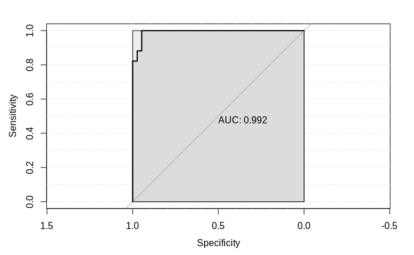

`r`r responce.PHY <- roc(prediction.class$is.PHY, prediction.class$pred.PHY, plot=TRUE, auc.polygon=TRUE, max.auc.polygon=TRUE, grid=TRUE, print.auc=TRUE, show.thres=TRUE, levels=c(0,1), direction=<)

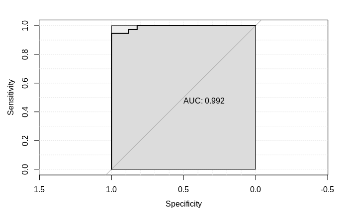

On peut remarquer que les deux courbes sont symétriques par rapport à x=-y + 1. C’est normal car les deux probabilités sont liées: P(psy) = 1 - P(phy)

Nous allons maintenant répeter toutes ces étapes n fois, en fonction du nombre de folds (plis) sélectionnés

`r`r get_auc <- function (m.PSY, m.PHY, nfolds) { result <- sapply(1:nfolds , function(fold) {

```
# construction des ensemble d'apprentissage et de test
splited_m.PSY <- split_data(nfolds, fold, m.PSY)
splited_m.PHY <- split_data(nfolds, fold, m.PHY)

# on determine les centroides
centroide.PSY <- colMeans(splited_m.PSY$train)
centroide.PHY <- colMeans(splited_m.PHY$train)

# on construit un nouveau data frame pour PSY
prediction.PSY <- data.frame(cours = rownames(splited_m.PSY$test),
                                     sim.PSY = as.double(cosinus.vm(centroide.PSY, t(splited_m.PSY$test))),
                                     sim.PHY = as.double(cosinus.vm(centroide.PHY, t(splited_m.PSY$test))))

prediction.PSY$pred.PSY <- apply(prediction.PSY, 1, function (v) {as.numeric(v['sim.PSY']) / (as.numeric(v['sim.PHY']) + as.numeric(v['sim.PSY']))})
prediction.PSY$pred.PHY <- apply(prediction.PSY, 1, function (v) {as.numeric(v['sim.PHY']) / (as.numeric(v['sim.PHY']) + as.numeric(v['sim.PSY']))})
prediction.PSY$is.PSY <- 1
prediction.PSY$is.PHY <- 0

# on construit un nouveau data frame pour PHY
prediction.PHY <- data.frame(cours = rownames(splited_m.PHY$test),
                                     sim.PSY = as.double(cosinus.vm(centroide.PSY, t(splited_m.PHY$test))),
                                     sim.PHY = as.double(cosinus.vm(centroide.PHY, t(splited_m.PHY$test))))

prediction.PHY$pred.PHY <- apply(prediction.PHY, 1, function (v) {as.numeric(v['sim.PHY']) / (as.numeric(v['sim.PHY']) + as.numeric(v['sim.PSY']))})
prediction.PHY$pred.PSY <- apply(prediction.PHY, 1, function (v) {as.numeric(v['sim.PSY']) / (as.numeric(v['sim.PHY']) + as.numeric(v['sim.PSY']))})
prediction.PHY$is.PHY <- 1
prediction.PHY$is.PSY <- 0

# on recupÃ¨re la valeur de AUC
prediction.class <- rbind(prediction.PHY, prediction.PSY)
responce.PSY <- roc(prediction.class$is.PSY, prediction.class$pred.PSY, levels=c(0,1), direction=\<\)
```

}) return(result) }

results <- as.data.frame(t(get_auc(reduce_tf_idf.PSY, reduce_tf_idf.PHY, 3))) mean(as.double(results$auc))

```
[1] 0.9963866
```

À partir de la fonction supérieure, nous allons essayer plusieurs dimensions de SVD.

`r`r get_auc_by_dimention <- function(dim_redu, tf_idf) {

m.svd <- irlba(t(tf_idf), dim_redu) reduce_tf_idf <- m.svd$u[, 1:dim_redu] %*% diag(m.svd$d[1:dim_redu]) rownames(reduce_tf_idf) <- colnames(tf_idf)

reduce_tf_idf.PSY <- subset(reduce_tf_idf, grepl(, rownames(reduce_tf_idf))) reduce_tf_idf.PHY <- subset(reduce_tf_idf, grepl(, rownames(reduce_tf_idf)))

results <- as.data.frame(t(get_auc(reduce_tf_idf.PSY, reduce_tf_idf.PHY, 3))) return(mean(as.double(results$auc))) } dim_min = 2 dim_max = 50 auc_by_dimentions <- mclapply(dim_min:dim_max, get_auc_by_dimention, tf_idf, mc.cores = detectCores()) plot(dim_min:dim_max, auc_by_dimentions, ylab = , xlab = de dimensions)

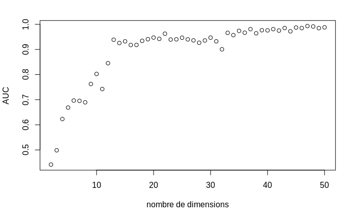

On peut voir qu’a partir d’une dimension de 30, les valeurs d’AUC sont presque parfaites. On peut donc se contenter d’une dimension de 30.

## Question 3

**Effectuez une agglomération par k-means (k=2) et vérifiez si les classes PHY et PSY sont bien séparées par cette méthode**

On s’assure qu’il n’y ai pas de valeur manquante :

`r`r sum(reduce_tf_idf.class[is.na(reduce_tf_idf.PSY)])

```
[1] 0
```

On peut donc procéder au K-mean sans se soucier des valeures manquantes. On va d’abord créer un ensemble de test et d’entrainement :

`r`r # apply_k_mean <- function(reduce_tf_idf.class) { nfolds = 3 splited_tf_idf.class <- split_data(nfolds, nfolds, reduce_tf_idf.class)

On exécute l’algorithme k-mean sur l’ensemble de test :

`r`r k_mean_res <- kmeans(splited_tf_idf.class$train, 2)

cluster.class <- data.frame(names = rownames(splited_tf_idf.class$train), cluster = as.numeric(k_mean_res$cluster)) head(cluster.class)

|  | names | cluster |
| --- | --- | --- |
| 1 | PHY1234.txt | 2 |
| 2 | PHY1441.txt | 2 |
| 3 | PHY1501.txt | 2 |
| 4 | PHY1620.txt | 2 |
| 5 | PHY1652.txt | 2 |
| 6 | PHY1901.txt | 2 |

On esssaye maintenant de deviner quel cluster correspond le mieux aux classes PHY et PSY: - on récupère les indices des classes réelles

`r`r index_PHY = grepl(, cluster.class$names) index_PSY = grepl(\PSY\, cluster.class$names)

cluster.class$is.PHY <- index_PHY cluster.class$is.PSY <- index_PSY

- on fait la moyenne des numéros de cluster pour chacune des classes

`r`r mean_cluster_PHY <- mean(cluster.class$cluster[index_PHY]) mean_cluster_PSY <- mean(cluster.class$cluster[index_PSY]) data.frame(classe_reelle = c(, ), moyenne_des_clusters = c(mean_cluster_PHY, mean_cluster_PSY))

| classe_reelle | moyenne_des_clusters |
| --- | --- |
| PHY | 2.000000 |
| PSY | 1.696154 |

On attribue le numéro du cluster à sa classe la plus proche :

`r`r num_cluster_PHY <- if(mean_cluster_PHY < mean_cluster_PSY) 1 else 2 num_cluster_PSY <- if(mean_cluster_PSY < mean_cluster_PHY) 1 else 2 data.frame(classe_reelle = c(, ), moyenne_des_clusters = c(num_cluster_PHY, num_cluster_PSY))

| classe_reelle | moyenne_des_clusters |
| --- | --- |
| PHY | 2 |
| PSY | 1 |

On peut maitenant attribuer un centroide aux classes :

`r`r centroide.PHY <- k_mean_res$centers[num_cluster_PHY,] centroide.PSY <- k_mean_res$centers[num_cluster_PSY,] data.frame(t(cbind(centroide.PHY, centroide.PSY)))

|  | X1 | X2 | X3 | X4 | X5 | X6 | X7 | X8 | X9 | X10 | X11 | X12 | X13 | X14 | X15 | X16 | X17 | X18 | X19 | X20 | X21 | X22 | X23 | X24 | X25 | X26 | X27 | X28 | X29 | … |
| --- | --- | --- | --- | --- | --- | --- | --- | --- | --- | --- | --- | --- | --- | --- | --- | --- | --- | --- | --- | --- | --- | --- | --- | --- | --- | --- | --- | --- | --- | --- |
| centroide.PHY | 0.1193832 | 2.260477 | 0.4579362 | -0.7736445 | -0.3330865 | 0.08414409 | 0.1297335 | 0.2469041 | -1.116094 | 0.6760285 | -0.08578608 | -0.05040098 | 0.2189954 | 0.9913032 | -0.5407695 | 0.16893369 | 0.3519402 | -0.1690247 | 0.4343669 | -0.01889667 | 0.00942223 | 0.04645326 | 0.2589513 | -0.05067198 | 0.2492754 | -0.1323245 | 0.7550126 | -0.4015764 | -0.3959228 | … |
| centroide.PSY | 0.2796415 | 5.534554 | 1.2636163 | -1.5482098 | -1.7525077 | -0.38653684 | -0.8555795 | -0.7538944 | -2.274097 | 0.7263561 | -0.25877723 | 0.89011117 | 1.5524888 | 0.4718562 | 0.7304734 | 0.05951731 | 1.4575818 | -0.4195983 | 2.2057266 | -0.11849456 | -0.16391195 | 0.52576485 | -0.1545905 | -0.26951144 | 0.6974809 | -1.1807542 | 2.5186551 | -0.1956766 | -0.7629526 | … |

On peut prévoir comme auparavant les classes par la similarité de chaque élement de l’ensemble de test et des deux centroides - on calcule la similarité de chaque element pour chaque centroide

`r`r prediction <- data.frame(cours = rownames(splited_tf_idf.class$test), sim.PSY = as.double(cosinus.vm(centroide.PSY, t(splited_tf_idf.class$test))), sim.PHY = as.double(cosinus.vm(centroide.PHY, t(splited_tf_idf.class$test)))) head(prediction)

|  | cours | sim.PSY | sim.PHY |
| --- | --- | --- | --- |
| 1 | PHY1651.txt | 0.1449847 | 0.6103197 |
| 2 | PHY1955.txt | 0.4381681 | 0.6982417 |
| 3 | PHY1972D.txt | 0.5853340 | 0.5593977 |
| 4 | PHY1984.txt | 0.2344322 | 0.3903754 |
| 5 | PHY1990.txt | 0.1868741 | 0.5908374 |
| 6 | PHY2300.txt | 0.2478216 | 0.5114622 |

- on normalise entre 0 et 1 pour obtenir une probabilité

`r`r prediction$pred.PSY <- apply(prediction, 1, function (v) {as.numeric(v['sim.PSY']) / (as.numeric(v['sim.PHY']) + as.numeric(v['sim.PSY']))}) prediction$pred.PHY <- apply(prediction, 1, function (v) {as.numeric(v[‘sim.PHY’]) / (as.numeric(v[‘sim.PHY’]) + as.numeric(v[‘sim.PSY’]))}) head(prediction)

|  | cours | sim.PSY | sim.PHY | pred.PSY | pred.PHY |
| --- | --- | --- | --- | --- | --- |
| 1 | PHY1651.txt | 0.1449847 | 0.6103197 | 0.1919553 | 0.8080447 |
| 2 | PHY1955.txt | 0.4381681 | 0.6982417 | 0.3855723 | 0.6144277 |
| 3 | PHY1972D.txt | 0.5853340 | 0.5593977 | 0.5113286 | 0.4886714 |
| 4 | PHY1984.txt | 0.2344322 | 0.3903754 | 0.3752070 | 0.6247930 |
| 5 | PHY1990.txt | 0.1868741 | 0.5908374 | 0.2402872 | 0.7597128 |
| 6 | PHY2300.txt | 0.2478216 | 0.5114622 | 0.3263887 | 0.6736113 |

On ajoute une colonne de labels des classes réelles pour faciliter la construction de la courbe de ROC par la suite :

`r`r prediction$is.PSY <- 0 prediction$is.PHY <- 0 prediction$is.PSY[grepl(\PSY\, prediction$cours)] <- 1 prediction$is.PHY[grepl(\PHY\, prediction$cours)] <- 1 head(prediction)

|  | cours | sim.PSY | sim.PHY | pred.PSY | pred.PHY | is.PSY | is.PHY |
| --- | --- | --- | --- | --- | --- | --- | --- |
| 1 | PHY1651.txt | 0.1449847 | 0.6103197 | 0.1919553 | 0.8080447 | 0 | 1 |
| 2 | PHY1955.txt | 0.4381681 | 0.6982417 | 0.3855723 | 0.6144277 | 0 | 1 |
| 3 | PHY1972D.txt | 0.5853340 | 0.5593977 | 0.5113286 | 0.4886714 | 0 | 1 |
| 4 | PHY1984.txt | 0.2344322 | 0.3903754 | 0.3752070 | 0.6247930 | 0 | 1 |
| 5 | PHY1990.txt | 0.1868741 | 0.5908374 | 0.2402872 | 0.7597128 | 0 | 1 |
| 6 | PHY2300.txt | 0.2478216 | 0.5114622 | 0.3263887 | 0.6736113 | 0 | 1 |

On peut analyser un peu ces résultats - on ajoute une colonne pour savoir si la prédiction est bonne

`r`r prediction$pred.right <- apply(prediction, 1, function(v) {(v[‘pred.PSY’] <= v[‘pred.PHY’] && v[‘is.PHY’] == 1) || (v[‘pred.PHY’] <= v[‘pred.PSY’] && v[‘is.PSY’] == 1)}) head(prediction)

|  | cours | sim.PSY | sim.PHY | pred.PSY | pred.PHY | is.PSY | is.PHY | pred.right |
| --- | --- | --- | --- | --- | --- | --- | --- | --- |
| 1 | PHY1651.txt | 0.1449847 | 0.6103197 | 0.1919553 | 0.8080447 | 0 | 1 | TRUE |
| 2 | PHY1955.txt | 0.4381681 | 0.6982417 | 0.3855723 | 0.6144277 | 0 | 1 | TRUE |
| 3 | PHY1972D.txt | 0.5853340 | 0.5593977 | 0.5113286 | 0.4886714 | 0 | 1 | FALSE |
| 4 | PHY1984.txt | 0.2344322 | 0.3903754 | 0.3752070 | 0.6247930 | 0 | 1 | TRUE |
| 5 | PHY1990.txt | 0.1868741 | 0.5908374 | 0.2402872 | 0.7597128 | 0 | 1 | TRUE |
| 6 | PHY2300.txt | 0.2478216 | 0.5114622 | 0.3263887 | 0.6736113 | 0 | 1 | TRUE |

On calcule toutes les données nécessaire à l’obtention de la précision, du rappel et du F1-score

`r`r view_prediction <- function(prediction_m) { prediction_m$pred.right <- apply(prediction_m, 1, function(v) {(v[‘pred.PSY’] <= v[‘pred.PHY’] && v[‘is.PHY’] == 1) || (v[‘pred.PHY’] <= v[‘pred.PSY’] && v[‘is.PSY’] == 1)})

TP.PSY <- length(which(prediction_m$pred.right==TRUE & prediction_m$is.PSY == 1)) FP.PSY <- length(which(prediction_m$pred.right==FALSE & prediction_m$is.PSY == 0)) TN.PSY <- length(which(prediction_m$pred.right==TRUE & prediction_m$is.PSY == 0)) FN.PSY <- length(which(prediction_m$pred.right==FALSE & prediction_m$is.PSY == 1))

TP.PHY <- length(which(prediction_m$pred.right==TRUE & prediction_m$is.PHY == 1)) FP.PHY <- length(which(prediction_m$pred.right==FALSE & prediction_m$is.PHY == 0)) TN.PHY <- length(which(prediction_m$pred.right==TRUE & prediction_m$is.PHY == 0)) FN.PHY <- length(which(prediction_m$pred.right==FALSE & prediction_m$is.PHY == 1))

acc.PHY <- sum(prediction_m$pred.right[prediction_m$is.PHY]) / length(prediction_m$is.PHY) acc.PSY <- sum(prediction_m$pred.right[prediction_m$is.PSY]) / length(prediction_m$is.PSY) acc <- sum(prediction_m$pred.right) / nrow(prediction_m)

precision.PSY <- TP.PSY / (TP.PSY + FP.PSY) precision.PHY <- TP.PHY / (TP.PHY + FP.PHY) precision <- (TP.PHY + TP.PSY) / (TP.PHY + FP.PHY + TP.PSY + FP.PSY)

recall.PSY <- TP.PSY / (TP.PSY + FN.PSY) recall.PHY <- TP.PHY / (TP.PHY + FN.PHY) recall <- (TP.PSY + TP.PHY) / (TP.PSY + FN.PSY + TP.PHY + FN.PHY)

F1_score.PSY <- 2 * precision.PSY * recall.PSY / (precision.PSY + recall.PSY) F1_score.PHY <- 2 * precision.PHY * recall.PHY / (precision.PHY + recall.PHY) F1_score <- 2 * precision * recall / (precision + recall)

data.frame(classe = c(, , ), accuracy = c(acc.PHY, acc.PSY, acc), precision = c(precision.PHY, precision.PSY, precision), recall = c(recall.PHY, recall.PSY, recall), F1_score = c(F1_score.PHY, F1_score.PSY, F1_score)) }

`r`r view_prediction(prediction)

| classe | accuracy | precision | recall | F1_score |
| --- | --- | --- | --- | --- |
| PHY | 0.150289 | 0.3243243 | 0.9230769 | 0.4800000 |
| PSY | 0.849711 | 0.9797980 | 0.6598639 | 0.7886179 |
| total | 0.699422 | 0.6994220 | 0.6994220 | 0.6994220 |

On peut observer plusieurs choses: - les deux classes sont deséquilibrées en accuracy, en précision et en recall - la précision est de presque 1 pour la classe PSY, mais le recall est médiocre - le recall est de presque 1 pour la classe PHY, mais la précision est médiocre

On peut maintenant construire une courbe ROC et une valeur d’AUC

`r`r prediction.roc <- roc(prediction$is.PSY, prediction$pred.PSY, levels=c(0,1), direction=<, plot=TRUE, auc.polygon=TRUE, max.auc.polygon=TRUE, grid=TRUE, print.auc=TRUE, show.thres=TRUE)

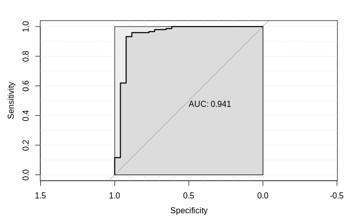

On obtient une valeur équivalente à la classification supervisée

On va maintenant mettre tout cela dans une fonction et faire des essais pour plusieurs valeurs de nombre de dimensions :

`r`r apply_k_mean <- function(m, nfolds, fold) { # sépration des données d’entrainement et de test splited_m <- split_data(nfolds, fold, m)

# algorithme k-mean k_mean_res <- kmeans(splited_m$train, 2)

# on attribut un numÃ©ro de cluster Ã chaque classe cluster.class <- data.frame(names = rownames(splited_m$train), cluster = as.numeric(k_mean_res$cluster))

index_PHY = grepl(, cluster.class$names) index_PSY = grepl(\PSY\, cluster.class$names)

cluster.class$is.PHY <- index_PHY cluster.class$is.PSY <- index_PSY

mean_cluster_PHY <- mean(cluster.class$cluster[index_PHY]) mean_cluster_PSY <- mean(cluster.class$cluster[index_PSY])

num_cluster_PHY <- if(mean_cluster_PHY < mean_cluster_PSY) 1 else 2 num_cluster_PSY <- if(mean_cluster_PSY < mean_cluster_PHY) 1 else 2

# on calcul les centroides centroide.PHY <- k_mean_res$centers[num_cluster_PHY,] centroide.PSY <- k_mean_res$centers[num_cluster_PSY,]

# on ajoute les similaritées prediction <- data.frame(cours = rownames(splited_m$test), sim.PSY = as.double(cosinus.vm(centroide.PSY, t(splited_m$test))), sim.PHY = as.double(cosinus.vm(centroide.PHY, t(splited_m$test)))) # on ajoute les prédictions prediction$pred.PSY <- apply(prediction, 1, function (v) {as.numeric(v[‘sim.PSY’]) / (as.numeric(v[‘sim.PHY’]) + as.numeric(v[‘sim.PSY’]))}) prediction$pred.PHY <- apply(prediction, 1, function (v) {as.numeric(v[‘sim.PHY’]) / (as.numeric(v[‘sim.PHY’]) + as.numeric(v[‘sim.PSY’]))})

# on ajoute les classes rÃ©elles prediction$is.PSY <- 0 prediction$is.PHY <- 0 prediction$is.PSY[grepl(\PSY\, prediction$cours)] <- 1 prediction$is.PHY[grepl(\PHY\, prediction$cours)] <- 1

return(prediction) }

On peut essayer d’améliorer les valeurs d’accuracy et de précision obtenues précédement. Une bonne manière d’effectuer cela est d’équilibrer le nombre d’elements par classe dans l’ensemble d’entrainement.

`r`r nb_max_cours <- min(nrow(reduce_tf_idf.PSY), nrow(reduce_tf_idf.PHY)) nb_max_cours

```
[1] 114
```

Nous allons donc limiter nos classes à 114 élements par classe.

On construit une matrice réduite contenant le même nombre d’élements des deux classes :

`r`r reduce_tf_idf.class.equi <- rbind(reduce_tf_idf.PSY[1:nb_max_cours,], reduce_tf_idf.PHY[1:nb_max_cours,])

On applique la fonction définie précédement pour obtenir les prédictions par k-mean :

`r`r prediction.equi <- apply_k_mean(reduce_tf_idf.class.equi, 5, 5) view_prediction(prediction.equi)

| classe | accuracy | precision | recall | F1_score |
| --- | --- | --- | --- | --- |
| PHY | 0.4888889 | 1.0000000 | 0.7727273 | 0.8717949 |
| PSY | 0.5111111 | 0.8214286 | 1.0000000 | 0.9019608 |
| total | 0.8888889 | 0.8888889 | 0.8888889 | 0.8888889 |

Cela a grandement amélioré nos différents indices.

On crée une fonction pour effecteur la k-fold cross-validation :

`r`r cross_validation_k_mean <- function(m, nfolds) { # on applique k fois l’algorithme sur les k sous ensemble test-entrainement result <- lapply(1:nfolds , function(fold) { # une application de l’algorithme sur un ensemble test-validation prediction <- apply_k_mean(m, nfolds, fold) prediction.roc <- roc(prediction$is.PSY, prediction$pred.PSY, levels=c(0,1), direction=<) return(prediction.roc$auc) }) }

results <- cross_validation_k_mean(reduce_tf_idf.class, 5) results.equi <- cross_validation_k_mean(reduce_tf_idf.class.equi, 5) data.frame(essais = 1:5, AUC = as.double(results), AUC_equi = as.double(results.equi))

| essais | AUC | AUC_equi |
| --- | --- | --- |
| 1 | 0.9935000 | 0.9561905 |
| 2 | 0.9792899 | 0.9961905 |
| 3 | 0.9739284 | 0.9848771 |
| 4 | 0.5686275 | 0.9940000 |
| 5 | 0.9832911 | 0.9560000 |

## Question 4

**À partir de la validation croisée de la tâche de classification ci-dessus, déterminez le nombre de dimensions latentes optimal de SVD selon une approche dite wrapper**

On réalise la même étude sur les dimensions que précédemment à partir des fonctions définies ci-dessus :

`r`r get_auc_by_dimention_kmean <- function(dim_redu, tf_idf) {

# rÃ©duction de dimention de la matrice TF-iDF m.svd <- irlba(t(tf_idf), dim_redu) reduce_tf_idf <- m.svd$u[, 1:dim_redu] %*% diag(m.svd$d[1:dim_redu]) rownames(reduce_tf_idf) <- colnames(tf_idf)

# on selectionne les classes PSY et PHY reduce_tf_idf.class <- subset(reduce_tf_idf, grepl(|PHY, rownames(reduce_tf_idf)))

# on rÃ©alise une 10-fold cross validation de l’algorithme k-mean results <- cross_validation_k_mean(reduce_tf_idf.class, 10)

# on renvoie la moyenne des valeur d’AUC sur ces classes return(mean(as.double(results))) }

`r`r dim_min = 2 dim_max = 50 auc_by_dimentions <- mclapply(dim_min:dim_max, get_auc_by_dimention_kmean, tf_idf, mc.cores = detectCores()) plot(dim_min:dim_max, auc_by_dimentions, ylab = , xlab = de dimensions)

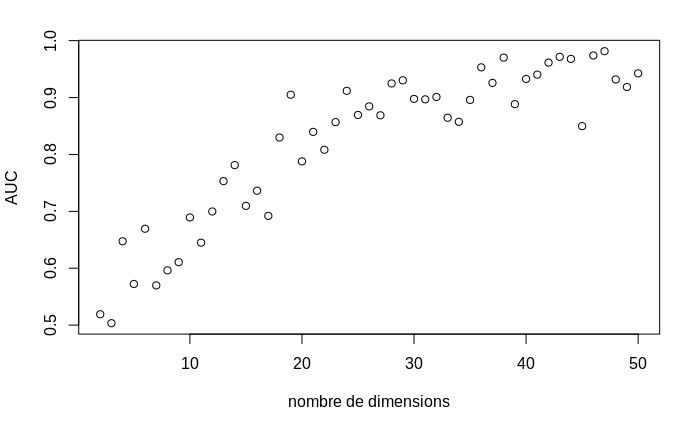

On peut voir que l’on approche presque 1 d’AUC sur plus de 35 dimensions, cela sera notre nombre optimal de dimensions

On peut maintenant se demander si on peut faire la réduction de dimension uniquement sur les cours PHY et PSY - on réduit la matrice de tf-idf à seulement les PSY et les PHY

`r`r tf_idf.class <- tf_idf[,grepl(|PHY, rownames(t(tf_idf)))]

- on réssaie avec la dimension 50

`r`r m.class.svd <- irlba(t(tf_idf.class), dim_redu) reduce_tf_idf.class <- m.class.svd$u[, 1:dim_redu] %*% diag(m.class.svd$d[1:dim_redu]) rownames(reduce_tf_idf.class) <- colnames(tf_idf.class)

prediction_reduction <- apply_k_mean(reduce_tf_idf.class, 5, 5) prediction_reduction.roc <- roc(prediction_reduction$is.PSY, prediction_reduction$pred.PSY, levels=c(0,1), direction=<, plot=TRUE, auc.polygon=TRUE, max.auc.polygon=TRUE, grid=TRUE, print.auc=TRUE, show.thres=TRUE)

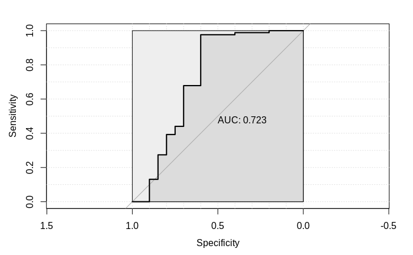

On peut voir que l’AUC est nettement pire. Cela peut être du au sur-apprentissage. Comme nous avons réduis les dimensions des ensembles de test drastiquement, le sur-apprentissage est forcément plus important.

- on essaie sur différentes valeurs de dimension

`r`r dim_min = 10 dim_max = 50 auc_by_dimentions <- mclapply(dim_min:dim_max, get_auc_by_dimention_kmean, tf_idf.class, mc.cores = detectCores()) plot(dim_min:dim_max, auc_by_dimentions, ylab = , xlab = de dimensions)

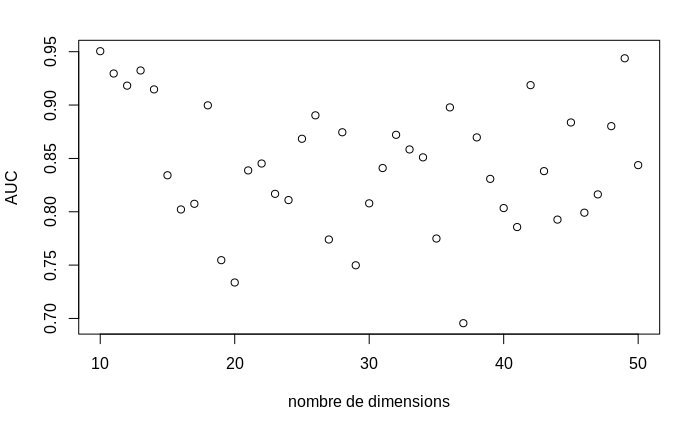

On peut voir que cela a tendance à rendre notre modèle inconsistant, et le fait légèrement sur-apprendre, pour une valeur moyenne de 0.8 d’AUC après 30 dimensions. La valeur optimale de dimension latente serait donc autour de 10.